# Capitulo I: Medición de cohesión social con ELSOC según modelo CEPAL

Kevin Carrasco

10-07-2021

# 1 Medición

El objetivo de esta consultoría es desarrollar un estudio sobre el estado de la cohesión social en Chile partiendo desde la noción y medición desarrollada en la nota conceptual “Cohesión social y desarrollo social inclusivo en América Latina” […] “Este servirá de punto de partida en las diferentes dimensiones, salvo cuando otras fuentes nacionales permitan un análisis más profundo y atingente. Este esquema de medición se presenta en la figura 1.

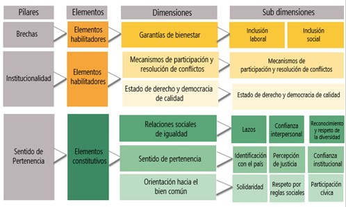

Figura 1: Resumen dimensiones CEPAL.

# 2 Elementos constitutivos de la cohesión social

## 2.1 Relaciones sociales de igualdad

### 2.1.1 Lazos

El indicador utilizado en el informe de CEPAL es “importancia de amigos en la vida”. Al trabajar con ELSOC se utilizará “Cantidad de amigos” (Ola 2 y 4)

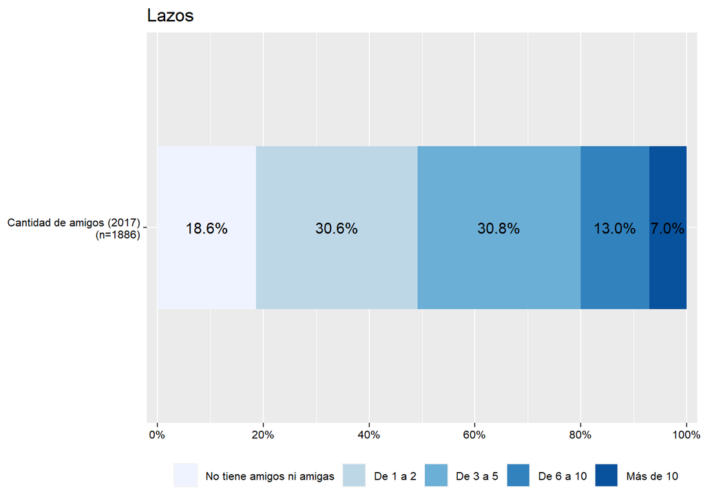

### 2.1.2 Confianza interpersonal

En el informe de CEPAL se utilizan los indicadores “Confianza en la gente de su comunidad” y “Confianza en la gente que se conoce por primera vez”. Al trabajar con ELSOC se utilizará “Se puede confiar en la mayoría de las personas”, “La mayoría de las personas tratar de ayudar a los demás” y “la mayoría de la gente trata de ser justa”, presentes en las cuatro olas.

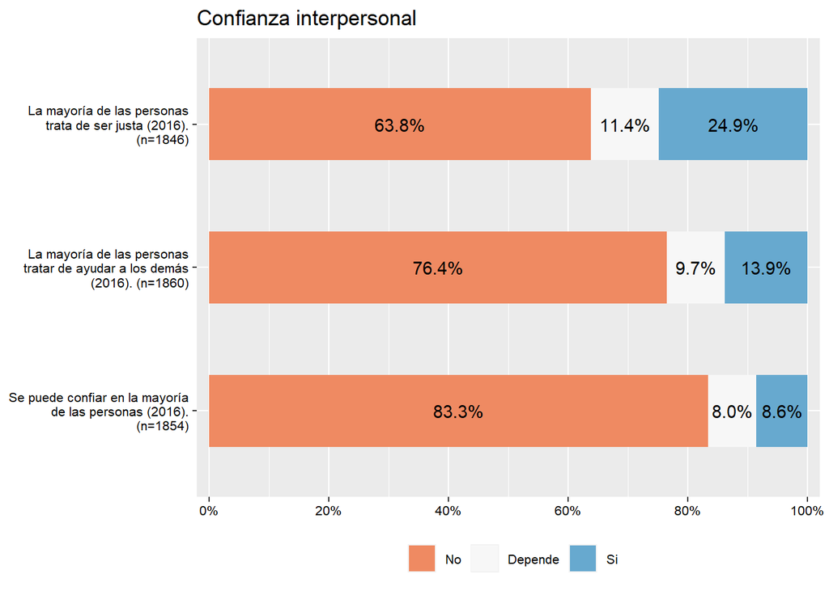

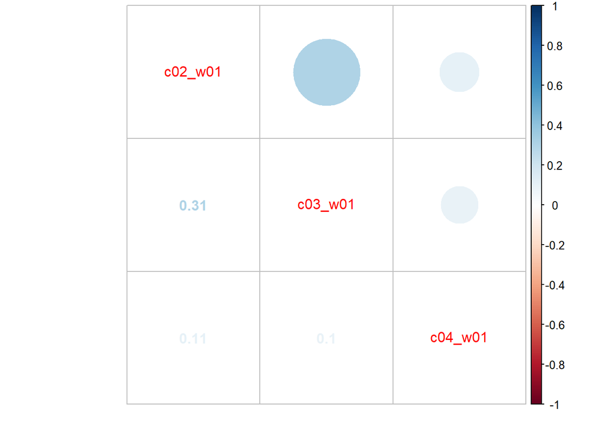

### 2.1.3 Reconocimiento y respeto de la diversidad

En el informe de CEPAL se utilizan dos indicadores “aprueba el derecho a contraer matrimonio de parejas del mismo sexo” y “Los hombres no tienen prioridad sobre la mujer, a la hora acceder a un trabajo” y se deja como pendiente la construcción de un indicador sobre tolerancia a personas de distinta raza y etnia, así como de percepción de discriminación. En este sentido, ante la falta de indicadores de ELSOC, se utilizarán los propuestos en [informe clases medias] como Actitudes hacia la diversidad: Los dos primeros en las cuatro olas, adopción homoparental en olas 3 y 4 y el resto en ola 2 y 4.

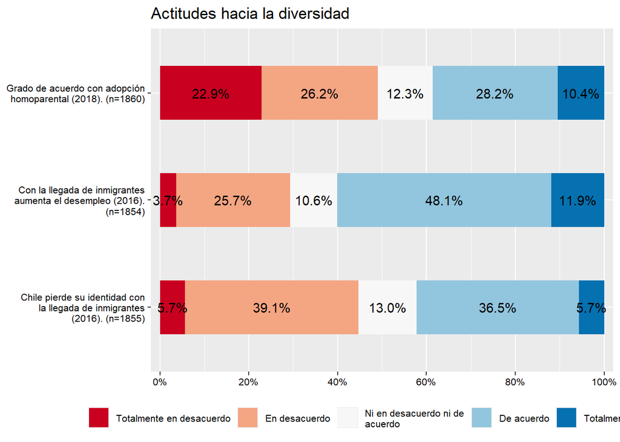

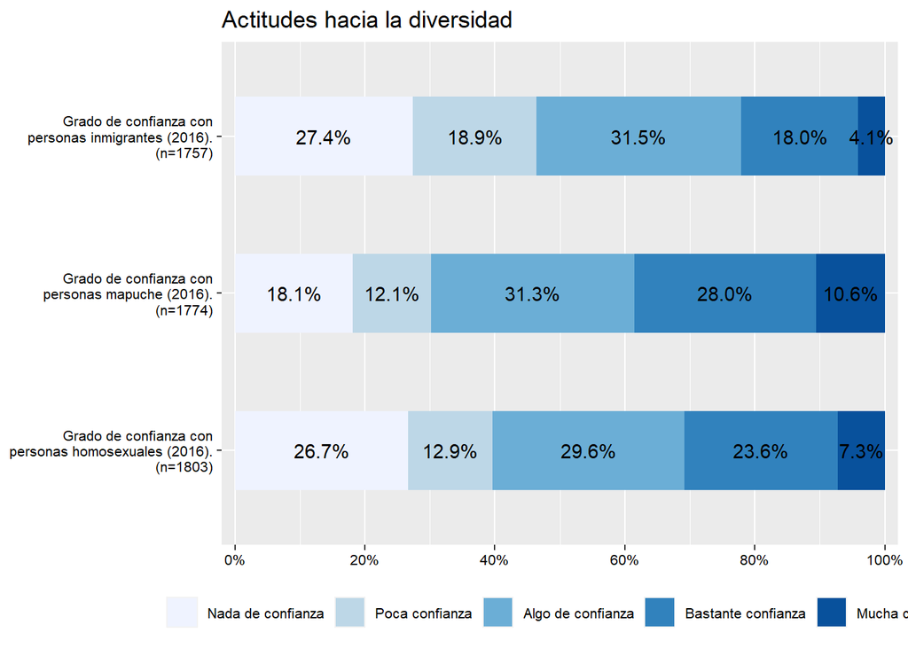

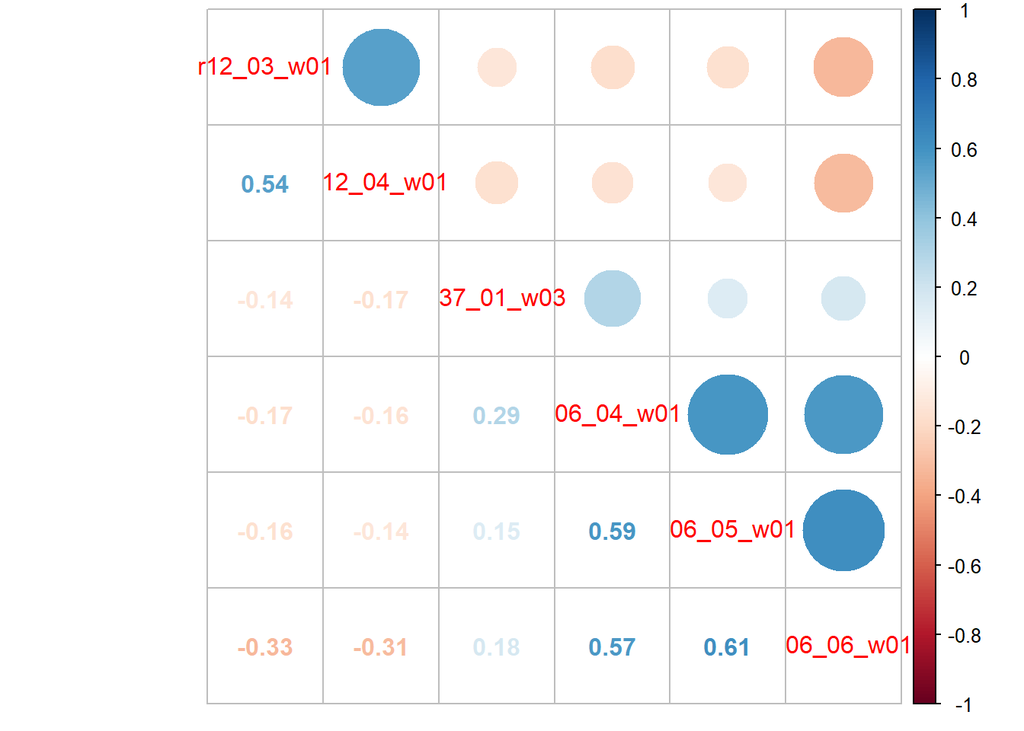

El ajuste de la dimensión Relaciones sociales de igualdad se estimó a través de un AFC. Esta dimensión logra su mejor ajuste al separarla en cuatro subdimensiones: a) Lazos; b) confianza interpersonal; c) Reconocimiento y respeto hacia la diversidad; y d) prejuicios hacia inmigrantes. Además, se excluye el indicador de “Grado de confianza en inmigrantes” de la subdimensión Reconocimiento y respeto hacia la diversidad.

```
##  chisq     df pvalue    cfi    tli  rmsea
## 30.622 15.000  0.010  0.990  0.982  0.025
```

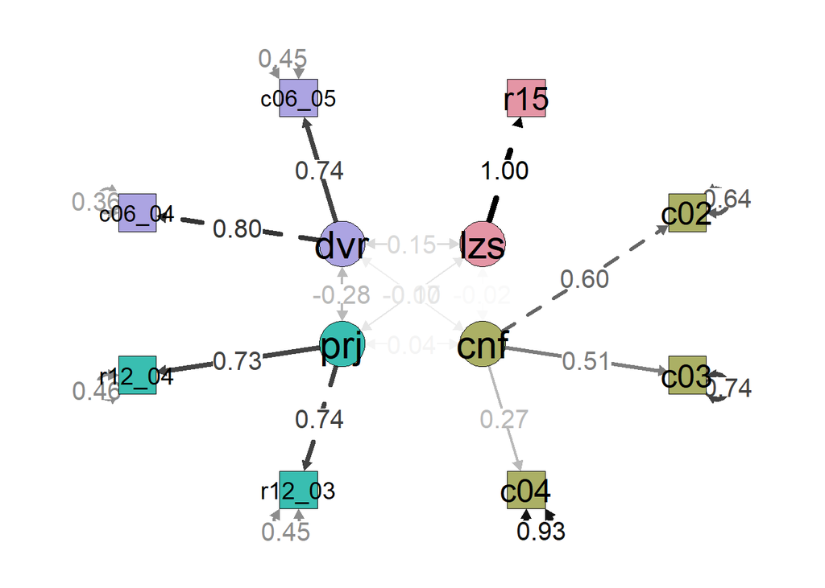

## 2.2 Sentido de pertenencia

### 2.2.1 Identificación con el país

En el informe CEPAL se incluyen los indicadores “Orgullo por el sistema político” y “Orgullo por su nacionalidad”. Al trabajar con ELSOC se utilizará “Orgullo de ser chileno” e “Identificación con Chile” que están presentes en las cuatro olas.

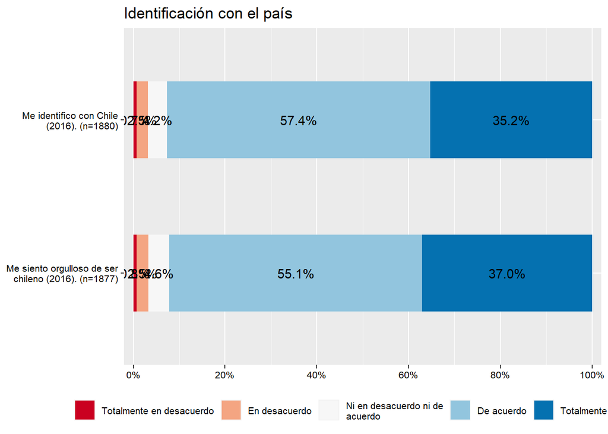

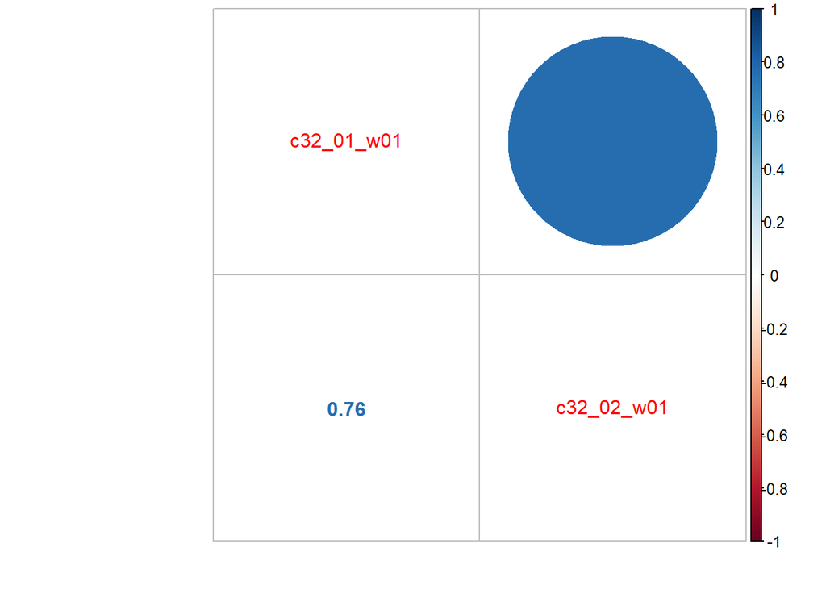

### 2.2.2 Percepción de justicia

En informe CEPAL se utilizan los indicadores “Se deben equiparar los sueldos, no mantener desigualdad para incentivar el esfuerzo personal”, “El trabajo a largo plazo da beneficios, no las conexiones o suerte”, “El Estado debe implementar políticas para reducir la desigualdad de ingreso”. Al trabajar con ELSOC se utilizan “En Chile las personas son recompensadas por su esfuerzo” y “En Chile las personas son recompensadas por su inteligencia”, presentes en todas las olas

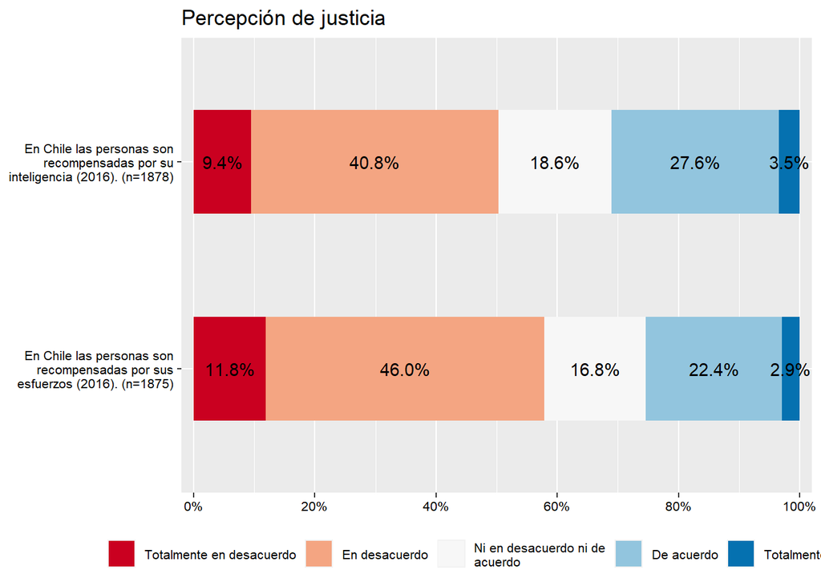

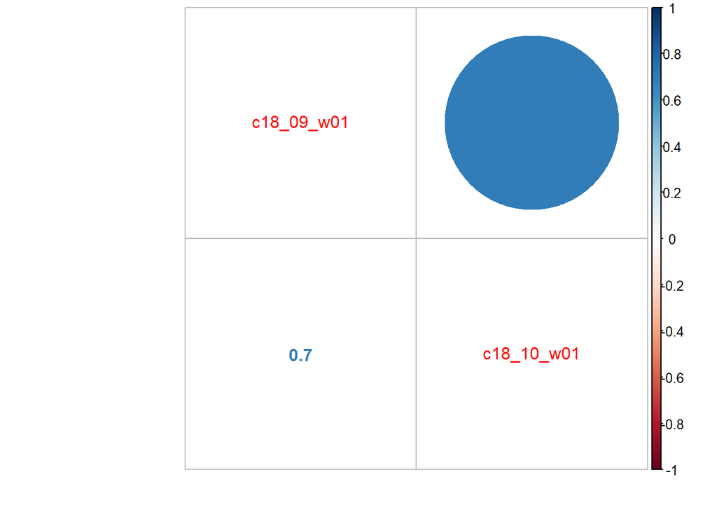

### 2.2.3 Confianza institucional

En informe CEPAL utilizan grado de confianza en (a) las cortes, (b) el Congreso Nacional, (c) la Policía Nacional, (d) los partidos políticos, (e) el ejecutivo y (f) las elecciones. Al trabajar con ELSOC se utilizan los siguientes ocho indicadores que están presentes en las cuatro olas

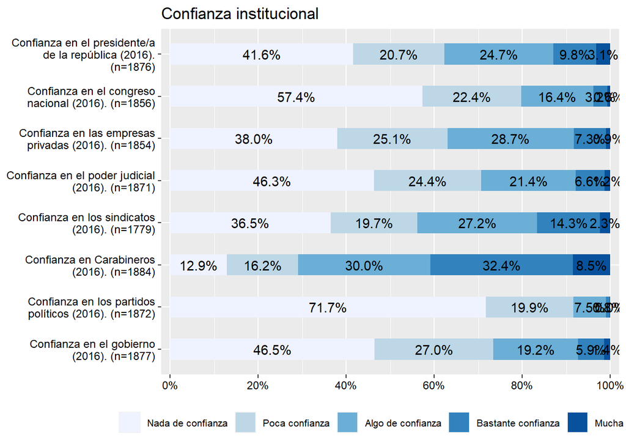

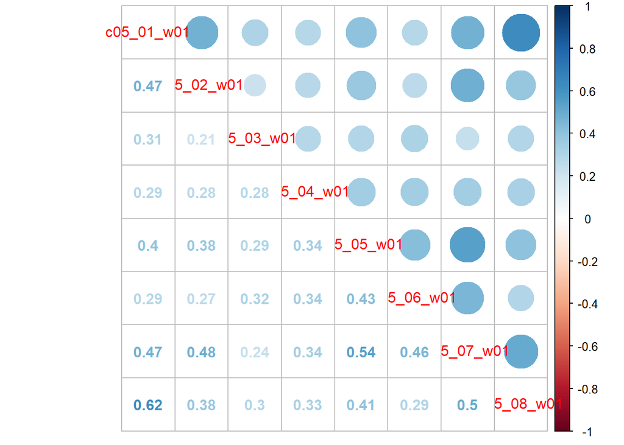

El ajuste de la dimensión Sentido de pertenencia se estimó a través de un AFC. Esta dimensión logra su mejor ajuste al ser separada en las tres subdimensiones propuestas por CEPAL: a) Identificación con el país; b) Percepción de justicia; y c) Confianza institucional. Además, se excluyen los indicadores “Confianza en el presidente/a” y “Confianza en los partidos políticos” de la subdimensión Confianza institucional.

```
##   chisq      df  pvalue     cfi     tli   rmsea
## 204.971  32.000   0.000   0.965   0.950   0.056
```

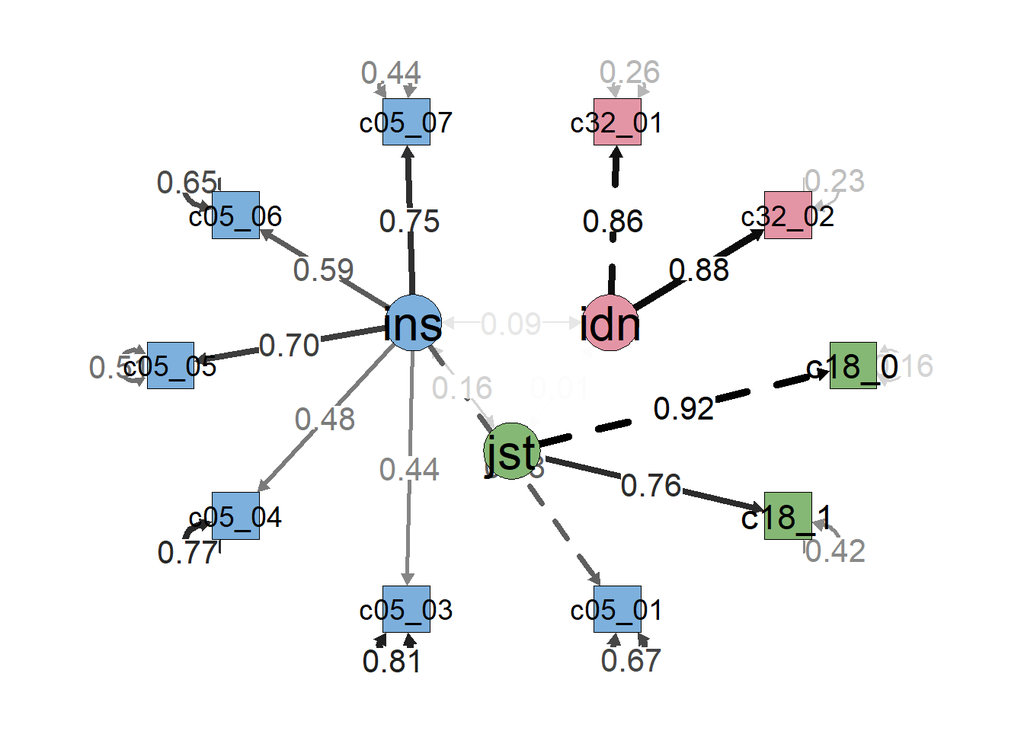

## 2.3 Orientación hacia el bien común

### 2.3.1 Solidaridad

En informe CEPAL utilizan el indicador “Asistencia a reuniones de un grupo de mejoras para la comunidad”. Al trabajar con ELSOC se utilizará este indicador y otros siete que abordan un comportamiento prosocial y que están presentes en las cuatro olas.

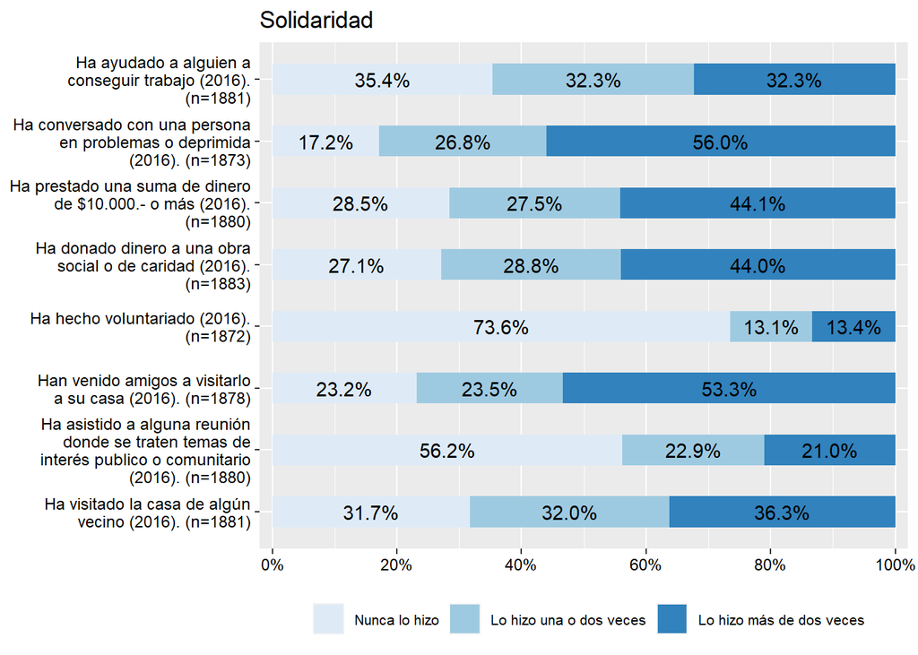

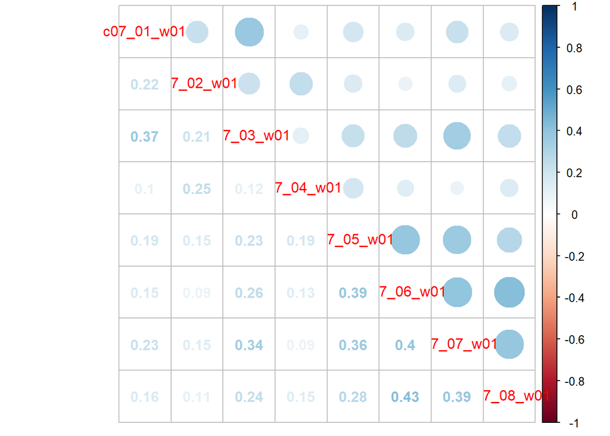

### 2.3.2 Participación cívica

En informe CEPAL se utilizaron los indicadores “Tiene actividad política (firma peticiones, boicot, va a manifestaciones pacíficas, huelgas)”, “Participación en organizaciones” y “Voto en elecciones presidenciales”. Al trabajar con ELSOC se utilizan cuatro indicadores de actividad política presentes en las cuatro olas, ocho indicadores de participación en organizaciones presentes en ola 1 y 3 y voto en elecciones 2013 y 2017 (ola 1 y 3)

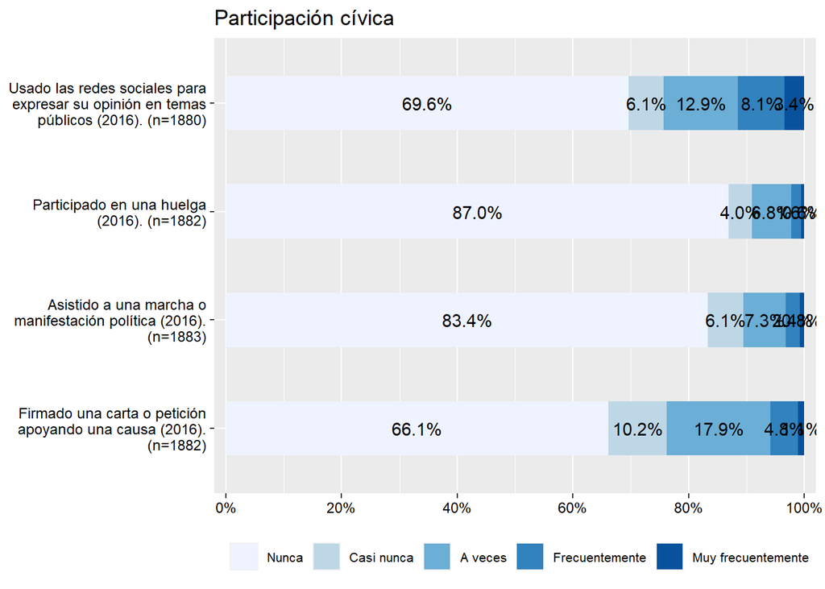

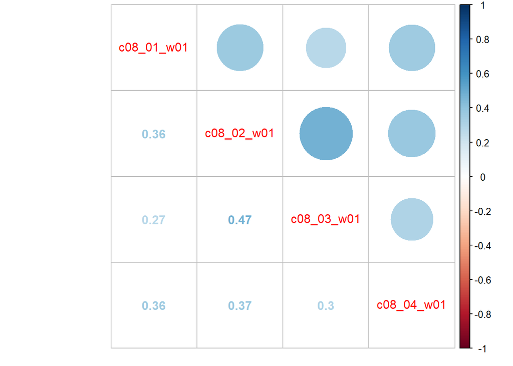

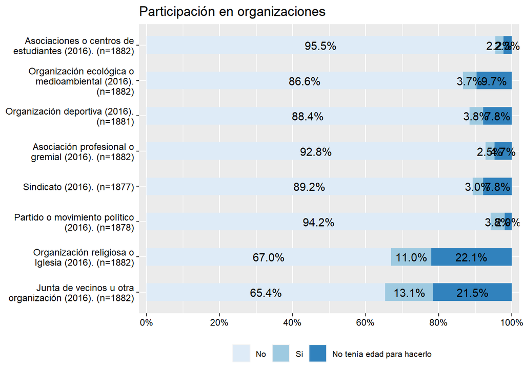

Para estimar esta correlación la categoría “No tenía edad para hacerlo” fue contabilizada como “No”

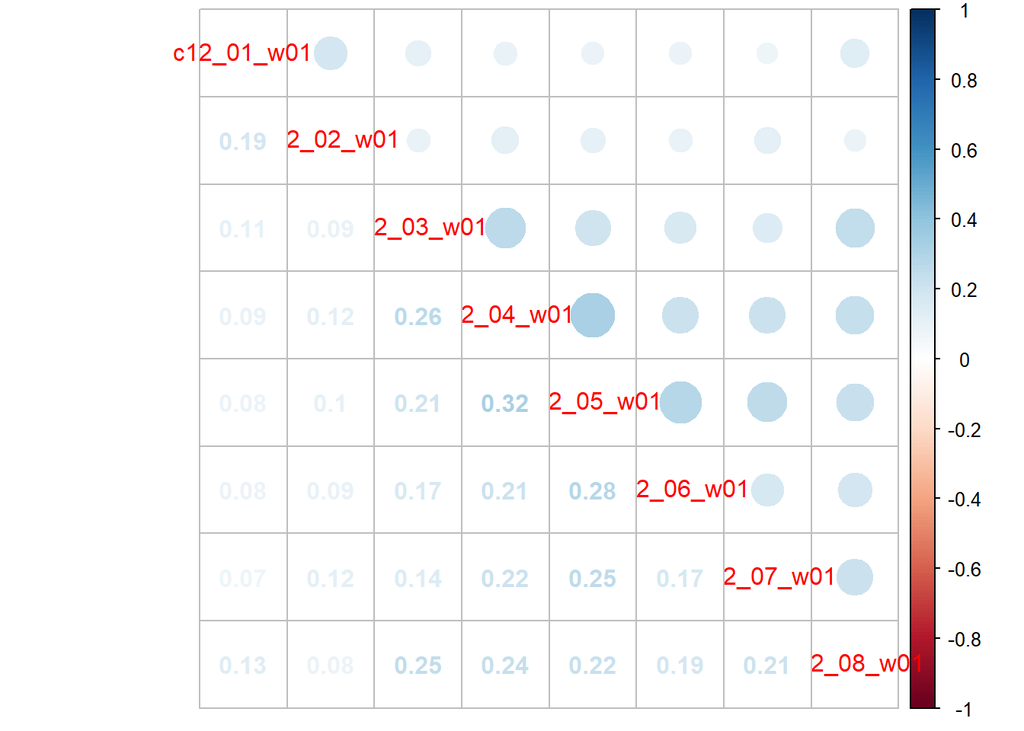

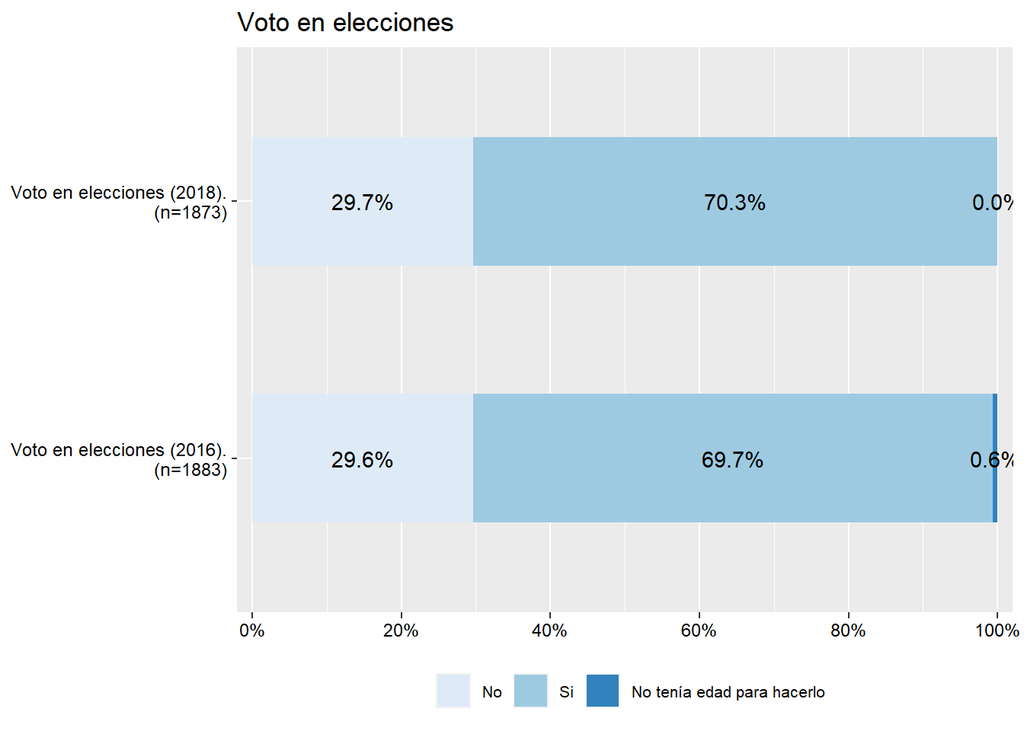

Para estimar esta correlación la categoría “No tenía edad para hacerlo” fue contabilizada como “No”.

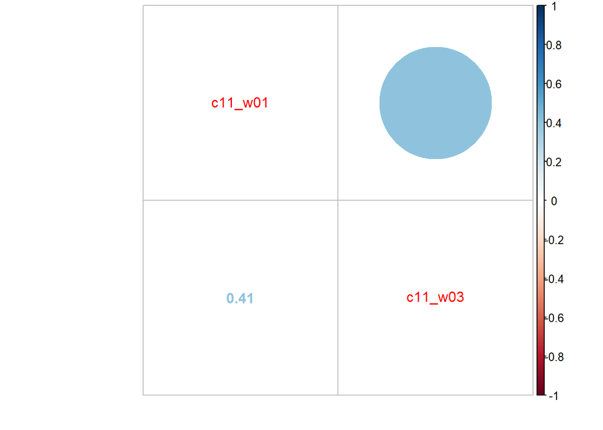

#### 2.3.2.1 No se incluye subdimensión respeto por reglas sociales de la dimensión Orientación hacia el bien comun de informe CEPAL, que posee un indicador de respeto por las instituciones inexistente en ELSOC

El ajuste de la dimensión Orientación hacia el bien común se estimó a través de un AFC. Esta dimensión logra su mejor ajuste al ser separada en cuatro subdimensiones: a) Solidaridad; b) Participación cívica; c) Participación en organizaciones y d) Participación electoral. Además, se excluyen los indicadores “Han venido amigos a visitarlo a su casa”, “Asiste a reuniones sobre temas de interés público”, “Ha hecho voluntariado” y “Ha ayudado a alguien a conseguir trabajo” de la subdimensión Solidaridad. El indicador “Participación en huelgas” de la subdimensión Participación cívica y el indicador “Organización religiosa” de la subdimensión Participación en organizaciones.

```
##   chisq      df  pvalue     cfi     tli   rmsea
## 185.857  85.000   0.000   0.961   0.952   0.026
```

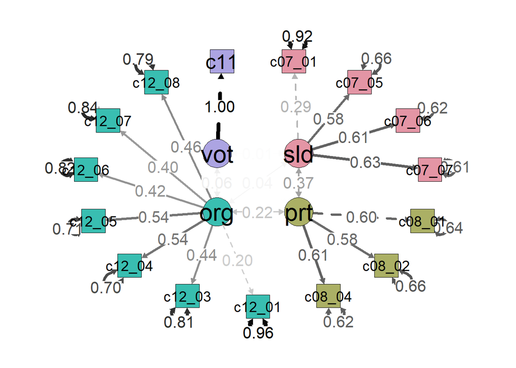

## 2.4 Calidad de vida en el vecindario

De manera adicional, se incorpora una dimensión sobre calidad de vida en el vecindario presente en ELSOC. Todos estos indicadores se encuentran presentes en las cuatro olas.

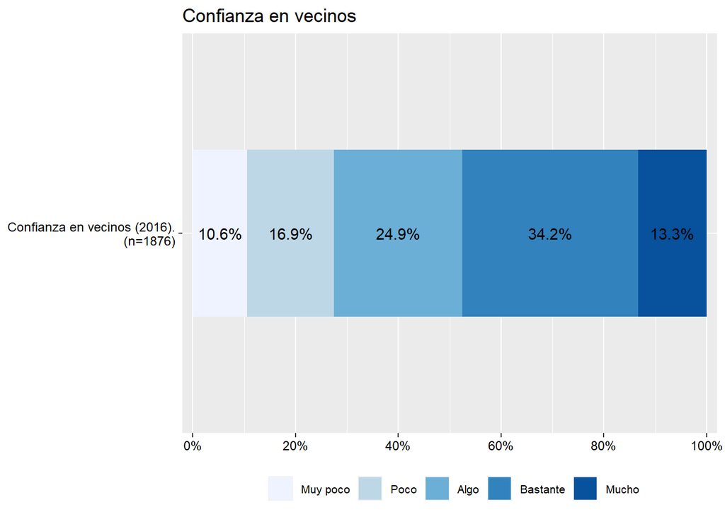

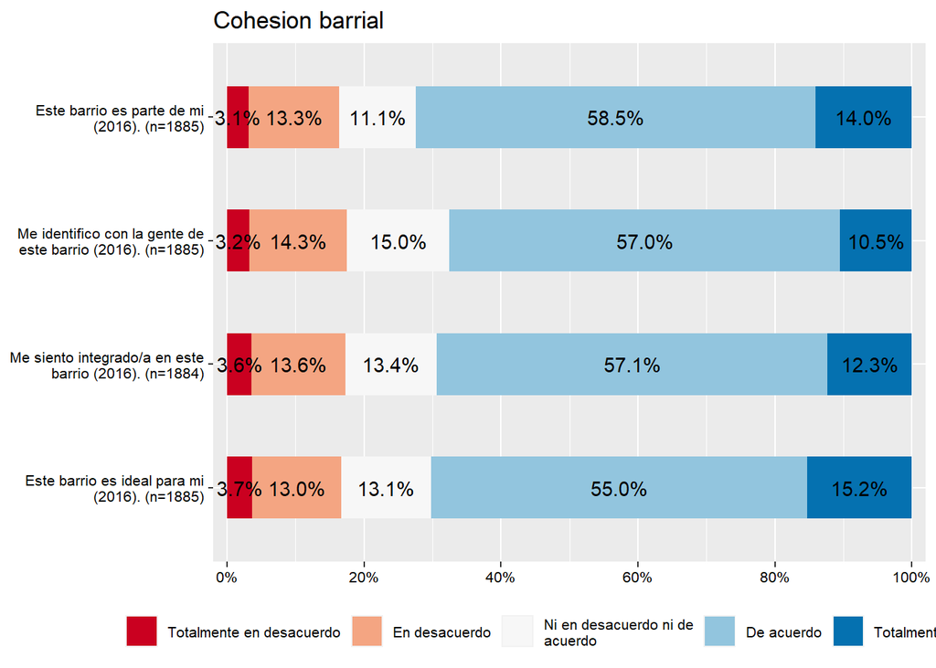

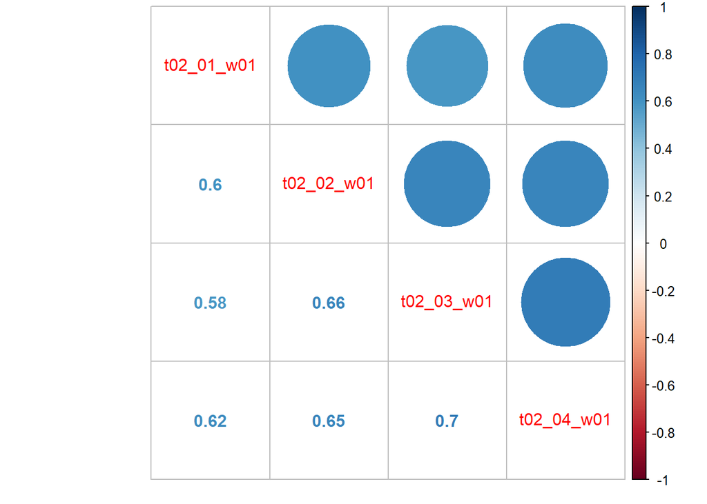

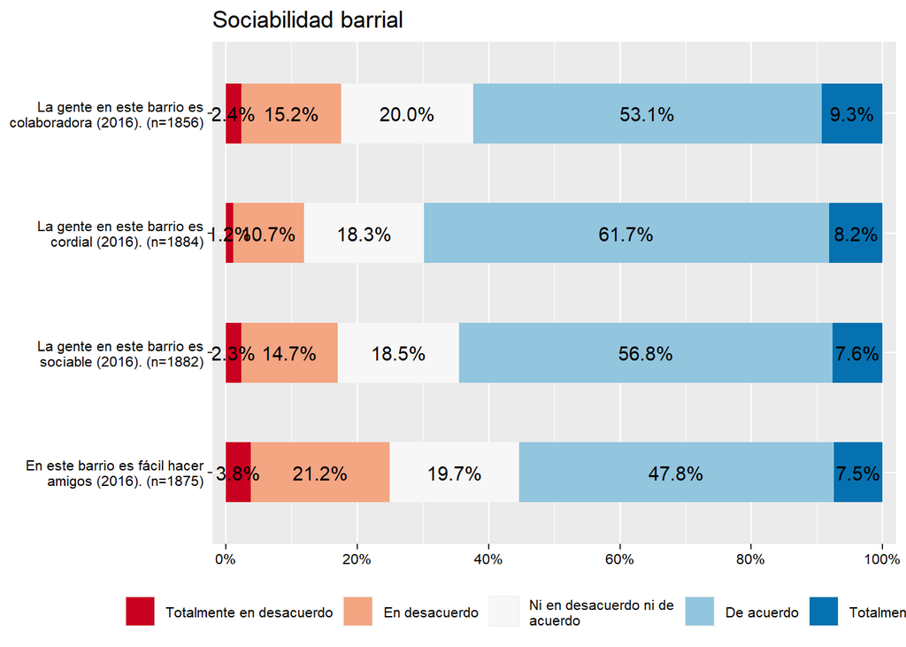

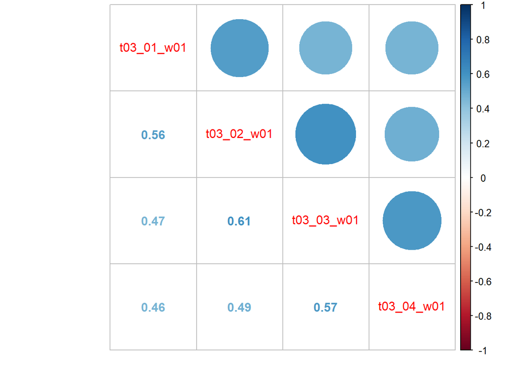

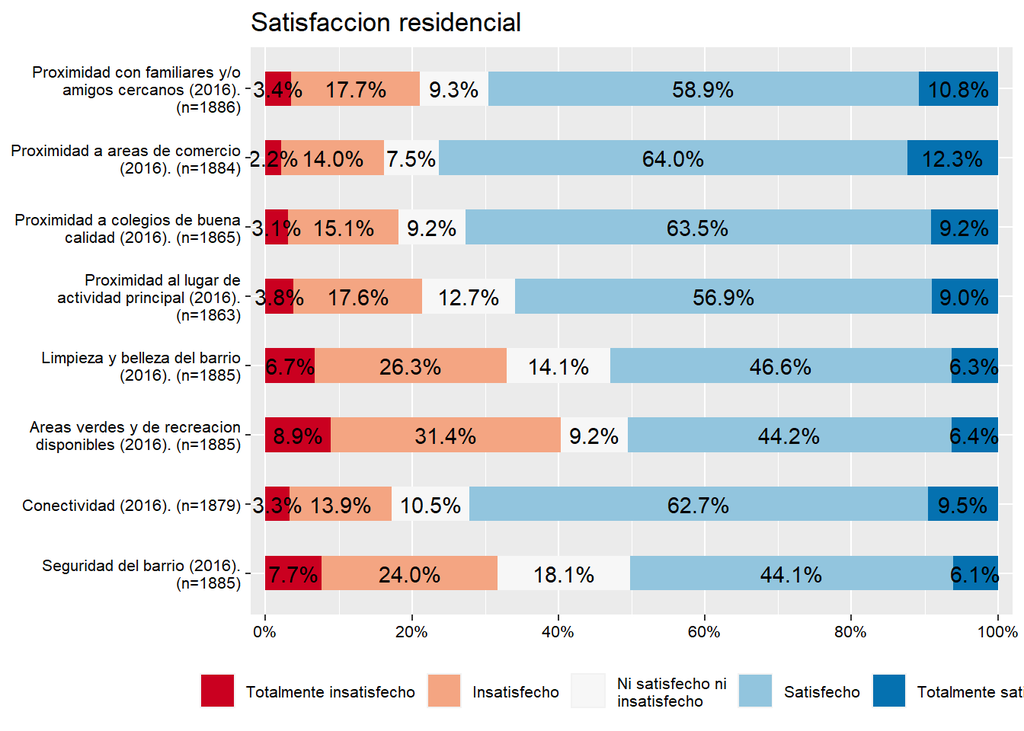

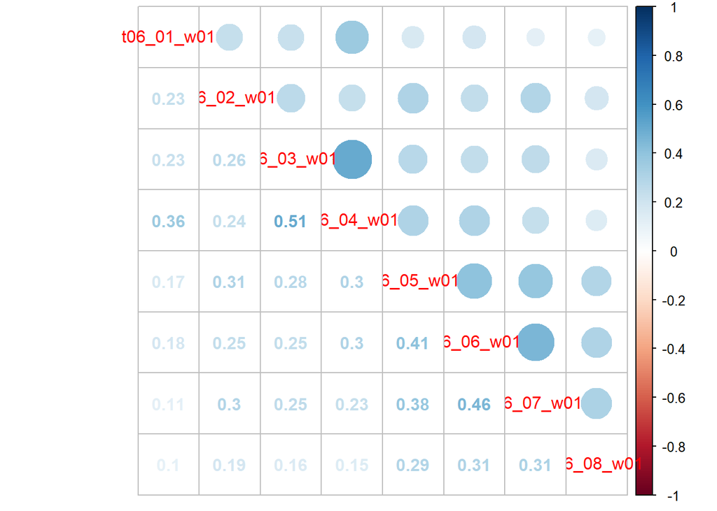

El ajuste de la dimensión Calidad de vida en el vecindario se estimó a través de un AFC. Esta dimensión logra su mejor ajuste al ser separada en cuatro subdimensiones: a) Confianza en vecinos; b) Cohesión barrial; c) Sociabilidad barrial y d) Satisfacción residencial. Además, se excluyen los indicadores “Seguridad en el vecindario” y “Limpieza y belleza del barrio” de la subdimensión Satisfacción residencial y el indicador “La gente del barrio es cordial” de la subdimensión Sociabilidad barrial

```
##   chisq      df  pvalue     cfi     tli   rmsea
## 223.108  72.000   0.000   0.980   0.975   0.034
```

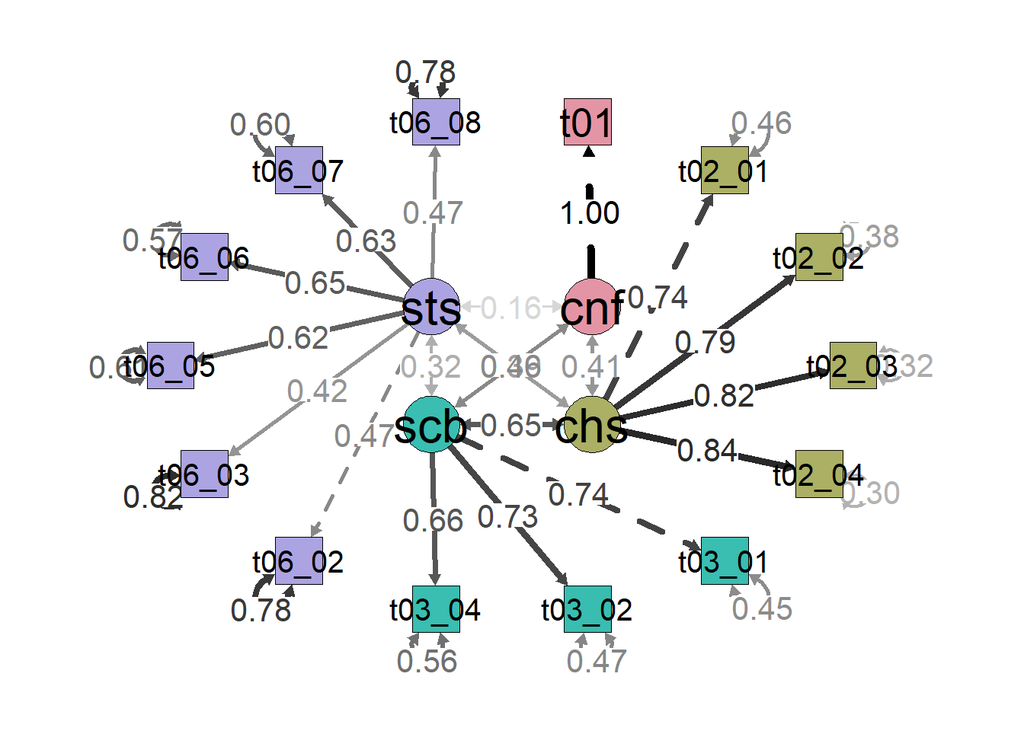